# Risk Factor Analysis

## Outcome Variable

**Outcome Variable:** haz

## Predictor Variables

**Intervention Variable:** gagebrth

**Adjustment Set:**

- arm
- sex
- W_mage
- meducyrs
- feducyrs
- hhwealth_quart
- W_nrooms
- brthmon
- W_parity
- impsan
- delta_W_mage
- delta_meducyrs
- delta_feducyrs
- delta_hhwealth_quart
- delta_W_nrooms
- delta_brthmon
- delta_W_parity
- delta_impsan

## Stratifying Variables

The analysis was stratified on these variable(s):

- agecat
- studyid
- country

## Data Summary

| agecat | studyid | country | gagebrth | n_cell | n |
| --- | --- | --- | --- | --- | --- |
| Birth | CMC-V-BCS-2002 | INDIA | Full or late term | 58 | 92 |
| Birth | CMC-V-BCS-2002 | INDIA | Preterm | 11 | 92 |
| Birth | CMC-V-BCS-2002 | INDIA | Early term | 23 | 92 |
| Birth | COHORTS | GUATEMALA | Full or late term | 341 | 617 |
| Birth | COHORTS | GUATEMALA | Preterm | 95 | 617 |
| Birth | COHORTS | GUATEMALA | Early term | 181 | 617 |
| Birth | COHORTS | INDIA | Full or late term | 570 | 1293 |
| Birth | COHORTS | INDIA | Preterm | 285 | 1293 |
| Birth | COHORTS | INDIA | Early term | 438 | 1293 |
| Birth | COHORTS | PHILIPPINES | Full or late term | 1164 | 3024 |
| Birth | COHORTS | PHILIPPINES | Preterm | 649 | 3024 |
| Birth | COHORTS | PHILIPPINES | Early term | 1211 | 3024 |
| Birth | IRC | INDIA | Full or late term | 238 | 369 |
| Birth | IRC | INDIA | Preterm | 36 | 369 |
| Birth | IRC | INDIA | Early term | 95 | 369 |
| Birth | JiVitA-3 | BANGLADESH | Full or late term | 10944 | 21442 |
| Birth | JiVitA-3 | BANGLADESH | Preterm | 4514 | 21442 |
| Birth | JiVitA-3 | BANGLADESH | Early term | 5984 | 21442 |
| Birth | Keneba | GAMBIA | Full or late term | 734 | 1515 |
| Birth | Keneba | GAMBIA | Preterm | 235 | 1515 |
| Birth | Keneba | GAMBIA | Early term | 546 | 1515 |
| Birth | NIH-Crypto | BANGLADESH | Full or late term | 162 | 732 |
| Birth | NIH-Crypto | BANGLADESH | Preterm | 257 | 732 |
| Birth | NIH-Crypto | BANGLADESH | Early term | 313 | 732 |
| Birth | PROBIT | BELARUS | Full or late term | 7100 | 13893 |
| Birth | PROBIT | BELARUS | Preterm | 472 | 13893 |
| Birth | PROBIT | BELARUS | Early term | 6321 | 13893 |
| 6 months | CMC-V-BCS-2002 | INDIA | Full or late term | 212 | 347 |
| 6 months | CMC-V-BCS-2002 | INDIA | Preterm | 52 | 347 |
| 6 months | CMC-V-BCS-2002 | INDIA | Early term | 83 | 347 |

[output cut: 57 more lines]

The following strata were considered:

- agecat: 24 months, studyid: CMC-V-BCS-2002, country: INDIA
- agecat: 24 months, studyid: COHORTS, country: GUATEMALA
- agecat: 24 months, studyid: COHORTS, country: INDIA
- agecat: 24 months, studyid: COHORTS, country: PHILIPPINES
- agecat: 24 months, studyid: IRC, country: INDIA
- agecat: 24 months, studyid: JiVitA-3, country: BANGLADESH
- agecat: 24 months, studyid: Keneba, country: GAMBIA
- agecat: 24 months, studyid: NIH-Crypto, country: BANGLADESH
- agecat: 24 months, studyid: PROBIT, country: BELARUS
- agecat: 24 months, studyid: TanzaniaChild2, country: TANZANIA, UNITED REPUBLIC OF
- agecat: 6 months, studyid: CMC-V-BCS-2002, country: INDIA
- agecat: 6 months, studyid: COHORTS, country: GUATEMALA
- agecat: 6 months, studyid: COHORTS, country: INDIA
- agecat: 6 months, studyid: COHORTS, country: PHILIPPINES
- agecat: 6 months, studyid: IRC, country: INDIA
- agecat: 6 months, studyid: JiVitA-3, country: BANGLADESH
- agecat: 6 months, studyid: Keneba, country: GAMBIA
- agecat: 6 months, studyid: NIH-Crypto, country: BANGLADESH
- agecat: 6 months, studyid: PROBIT, country: BELARUS
- agecat: 6 months, studyid: TanzaniaChild2, country: TANZANIA, UNITED REPUBLIC OF
- agecat: Birth, studyid: CMC-V-BCS-2002, country: INDIA
- agecat: Birth, studyid: COHORTS, country: GUATEMALA
- agecat: Birth, studyid: COHORTS, country: INDIA
- agecat: Birth, studyid: COHORTS, country: PHILIPPINES
- agecat: Birth, studyid: IRC, country: INDIA
- agecat: Birth, studyid: JiVitA-3, country: BANGLADESH
- agecat: Birth, studyid: Keneba, country: GAMBIA
- agecat: Birth, studyid: NIH-Crypto, country: BANGLADESH
- agecat: Birth, studyid: PROBIT, country: BELARUS

### Dropped Strata

Some strata were dropped due to rare outcomes:

- agecat: 24 months, studyid: TanzaniaChild2, country: TANZANIA, UNITED REPUBLIC OF

## Methods Detail

We’re interested in the causal parameters $E[Y_a]$ for all values of $a \in \mathcal{A}$. These parameters represent the mean outcome if, possibly contrary to fact, we intervened to set all units to have $A=a$. Under the randomization and positivity assumptions, these are identified by the statistical parameters $\psi_a=E_W[E_{Y|A,W}(Y|A=a,W)]$. In addition, we’re interested in the mean of $Y$, $E[Y]$ under no intervention (the observed mean). We will estimate these parameters by using SuperLearner to fit the relevant likelihood factors – $E_{Y|A,W}(Y|A=a,W)$ and $p(A=a|W)$, and then updating our likelihood fit using a joint TMLE.

For unadjusted analyses ($W=\{\}$), initial likelihoods were estimated using Lrnr_glm to estimate the simple $E(Y|A)$ and Lrnr_mean to estimate $p(A)$. For adjusted analyses, a small library containing Lrnr_glmnet, Lrnr_xgboost, and Lrnr_mean was used.

Having estimated these parameters, we will then use the delta method to estimate relative risks and attributable risks relative to a prespecified baseline level of $A$.

# Results Detail

## Results Plots

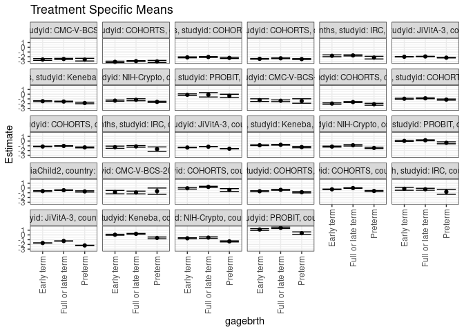

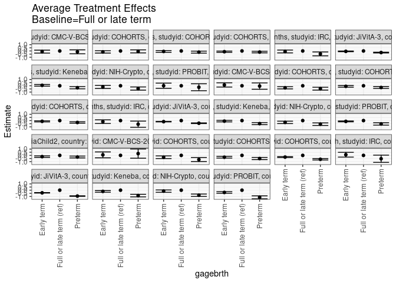

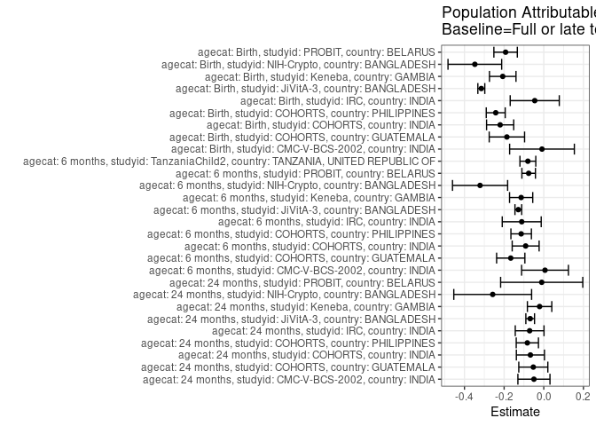

## Results Table

### Parameter: TSM

| agecat | studyid | country | intervention_level | baseline_level | estimate | ci_lower | ci_upper |
| --- | --- | --- | --- | --- | --- | --- | --- |
| Birth | CMC-V-BCS-2002 | INDIA | Full or late term | NA | -0.9521579 | -1.2459700 | -0.6583458 |
| Birth | CMC-V-BCS-2002 | INDIA | Preterm | NA | -0.6674272 | -1.3346568 | -0.0001975 |
| Birth | CMC-V-BCS-2002 | INDIA | Early term | NA | -0.8705668 | -1.2341310 | -0.5070026 |
| Birth | COHORTS | GUATEMALA | Full or late term | NA | 0.2391002 | 0.1148756 | 0.3633247 |
| Birth | COHORTS | GUATEMALA | Preterm | NA | -0.4271436 | -0.7217894 | -0.1324978 |
| Birth | COHORTS | GUATEMALA | Early term | NA | -0.0562517 | -0.2279607 | 0.1154572 |
| Birth | COHORTS | INDIA | Full or late term | NA | -0.3871239 | -0.4756602 | -0.2985876 |
| Birth | COHORTS | INDIA | Preterm | NA | -0.8872508 | -1.0286750 | -0.7458267 |
| Birth | COHORTS | INDIA | Early term | NA | -0.6795744 | -0.7789991 | -0.5801498 |
| Birth | COHORTS | PHILIPPINES | Full or late term | NA | -0.0069126 | -0.0650970 | 0.0512717 |
| Birth | COHORTS | PHILIPPINES | Preterm | NA | -0.6321716 | -0.7300345 | -0.5343088 |
| Birth | COHORTS | PHILIPPINES | Early term | NA | -0.2783625 | -0.3350782 | -0.2216468 |
| Birth | IRC | INDIA | Full or late term | NA | -0.2647003 | -0.4696940 | -0.0597067 |
| Birth | IRC | INDIA | Preterm | NA | -0.8022823 | -1.3358014 | -0.2687633 |
| Birth | IRC | INDIA | Early term | NA | -0.1585138 | -0.4749743 | 0.1579468 |
| Birth | JiVitA-3 | BANGLADESH | Full or late term | NA | -1.2830686 | -1.3065557 | -1.2595815 |
| Birth | JiVitA-3 | BANGLADESH | Preterm | NA | -2.2194400 | -2.2638596 | -2.1750203 |
| Birth | JiVitA-3 | BANGLADESH | Early term | NA | -1.7035746 | -1.7340889 | -1.6730603 |
| Birth | Keneba | GAMBIA | Full or late term | NA | 0.2349200 | 0.1481897 | 0.3216502 |
| Birth | Keneba | GAMBIA | Preterm | NA | -0.6244899 | -0.8085944 | -0.4403854 |
| Birth | Keneba | GAMBIA | Early term | NA | 0.0423660 | -0.0591349 | 0.1438668 |
| Birth | NIH-Crypto | BANGLADESH | Full or late term | NA | -0.5618081 | -0.7133669 | -0.4102493 |
| Birth | NIH-Crypto | BANGLADESH | Preterm | NA | -1.3640246 | -1.4786999 | -1.2493492 |
| Birth | NIH-Crypto | BANGLADESH | Early term | NA | -0.7085533 | -0.8111401 | -0.6059665 |
| Birth | PROBIT | BELARUS | Full or late term | NA | 1.5040099 | 1.3497945 | 1.6582253 |
| Birth | PROBIT | BELARUS | Preterm | NA | 0.3680671 | 0.0967357 | 0.6393986 |
| Birth | PROBIT | BELARUS | Early term | NA | 1.1446707 | 0.9603664 | 1.3289749 |
| 6 months | CMC-V-BCS-2002 | INDIA | Full or late term | NA | -1.3917842 | -1.5740516 | -1.2095169 |
| 6 months | CMC-V-BCS-2002 | INDIA | Preterm | NA | -1.4419954 | -1.9135489 | -0.9704418 |
| 6 months | CMC-V-BCS-2002 | INDIA | Early term | NA | -1.2597945 | -1.5409428 | -0.9786462 |

[output cut: 54 more lines]

### Parameter: E(Y)

| agecat | studyid | country | intervention_level | baseline_level | estimate | ci_lower | ci_upper |
| --- | --- | --- | --- | --- | --- | --- | --- |
| Birth | CMC-V-BCS-2002 | INDIA | NA | NA | -0.9611957 | -1.1776967 | -0.7446946 |
| Birth | COHORTS | GUATEMALA | NA | NA | 0.0530794 | -0.0441925 | 0.1503513 |
| Birth | COHORTS | INDIA | NA | NA | -0.6072158 | -0.6675691 | -0.5468624 |
| Birth | COHORTS | PHILIPPINES | NA | NA | -0.2492460 | -0.2884729 | -0.2100192 |
| Birth | IRC | INDIA | NA | NA | -0.3102981 | -0.4751168 | -0.1454794 |
| Birth | JiVitA-3 | BANGLADESH | NA | NA | -1.5980879 | -1.6176172 | -1.5785586 |
| Birth | Keneba | GAMBIA | NA | NA | 0.0278680 | -0.0365315 | 0.0922674 |
| Birth | NIH-Crypto | BANGLADESH | NA | NA | -0.9094945 | -0.9809370 | -0.8380521 |
| Birth | PROBIT | BELARUS | NA | NA | 1.3114417 | 1.1524752 | 1.4704082 |
| 6 months | CMC-V-BCS-2002 | INDIA | NA | NA | -1.3856004 | -1.5319935 | -1.2392072 |
| 6 months | COHORTS | GUATEMALA | NA | NA | -1.8315428 | -1.9081267 | -1.7549589 |
| 6 months | COHORTS | INDIA | NA | NA | -0.9630335 | -1.0220763 | -0.9039908 |
| 6 months | COHORTS | PHILIPPINES | NA | NA | -1.1409862 | -1.1830414 | -1.0989310 |
| 6 months | IRC | INDIA | NA | NA | -1.2321263 | -1.3660720 | -1.0981806 |
| 6 months | JiVitA-3 | BANGLADESH | NA | NA | -1.3168751 | -1.3402193 | -1.2935309 |
| 6 months | Keneba | GAMBIA | NA | NA | -0.8948084 | -0.9510697 | -0.8385471 |
| 6 months | NIH-Crypto | BANGLADESH | NA | NA | -1.1986783 | -1.2700937 | -1.1272630 |
| 6 months | PROBIT | BELARUS | NA | NA | 0.0980074 | 0.0062724 | 0.1897424 |
| 6 months | TanzaniaChild2 | TANZANIA, UNITED REPUBLIC OF | NA | NA | -0.5419570 | -0.5926042 | -0.4913098 |
| 24 months | CMC-V-BCS-2002 | INDIA | NA | NA | -2.5319389 | -2.6335015 | -2.4303762 |
| 24 months | COHORTS | GUATEMALA | NA | NA | -2.9911195 | -3.0733804 | -2.9088586 |
| 24 months | COHORTS | INDIA | NA | NA | -2.1289450 | -2.1901830 | -2.0677069 |
| 24 months | COHORTS | PHILIPPINES | NA | NA | -2.4144884 | -2.4596605 | -2.3693164 |
| 24 months | IRC | INDIA | NA | NA | -1.7964915 | -1.8912047 | -1.7017782 |
| 24 months | JiVitA-3 | BANGLADESH | NA | NA | -2.0156596 | -2.0439781 | -1.9873411 |
| 24 months | Keneba | GAMBIA | NA | NA | -1.5800865 | -1.6398819 | -1.5202911 |
| 24 months | NIH-Crypto | BANGLADESH | NA | NA | -1.4412646 | -1.5249156 | -1.3576135 |
| 24 months | PROBIT | BELARUS | NA | NA | -0.1442891 | -0.4253755 | 0.1367972 |

### Parameter: ATE

| agecat | studyid | country | intervention_level | baseline_level | estimate | ci_lower | ci_upper |
| --- | --- | --- | --- | --- | --- | --- | --- |
| Birth | CMC-V-BCS-2002 | INDIA | Full or late term | Full or late term | 0.0000000 | 0.0000000 | 0.0000000 |
| Birth | CMC-V-BCS-2002 | INDIA | Preterm | Full or late term | 0.2847308 | -0.4484716 | 1.0179331 |
| Birth | CMC-V-BCS-2002 | INDIA | Early term | Full or late term | 0.0815911 | -0.3862622 | 0.5494445 |
| Birth | COHORTS | GUATEMALA | Full or late term | Full or late term | 0.0000000 | 0.0000000 | 0.0000000 |
| Birth | COHORTS | GUATEMALA | Preterm | Full or late term | -0.6662437 | -0.9861990 | -0.3462885 |
| Birth | COHORTS | GUATEMALA | Early term | Full or late term | -0.2953519 | -0.5074187 | -0.0832851 |
| Birth | COHORTS | INDIA | Full or late term | Full or late term | 0.0000000 | 0.0000000 | 0.0000000 |
| Birth | COHORTS | INDIA | Preterm | Full or late term | -0.5001270 | -0.6673125 | -0.3329414 |
| Birth | COHORTS | INDIA | Early term | Full or late term | -0.2924506 | -0.4252361 | -0.1596650 |
| Birth | COHORTS | PHILIPPINES | Full or late term | Full or late term | 0.0000000 | 0.0000000 | 0.0000000 |
| Birth | COHORTS | PHILIPPINES | Preterm | Full or late term | -0.6252590 | -0.7388943 | -0.5116236 |
| Birth | COHORTS | PHILIPPINES | Early term | Full or late term | -0.2714499 | -0.3523192 | -0.1905805 |
| Birth | IRC | INDIA | Full or late term | Full or late term | 0.0000000 | 0.0000000 | 0.0000000 |
| Birth | IRC | INDIA | Preterm | Full or late term | -0.5375820 | -1.1092861 | 0.0341221 |
| Birth | IRC | INDIA | Early term | Full or late term | 0.1061866 | -0.2713561 | 0.4837293 |
| Birth | JiVitA-3 | BANGLADESH | Full or late term | Full or late term | 0.0000000 | 0.0000000 | 0.0000000 |
| Birth | JiVitA-3 | BANGLADESH | Preterm | Full or late term | -0.9363714 | -0.9870486 | -0.8856942 |
| Birth | JiVitA-3 | BANGLADESH | Early term | Full or late term | -0.4205061 | -0.4560537 | -0.3849584 |
| Birth | Keneba | GAMBIA | Full or late term | Full or late term | 0.0000000 | 0.0000000 | 0.0000000 |
| Birth | Keneba | GAMBIA | Preterm | Full or late term | -0.8594099 | -1.0628729 | -0.6559469 |
| Birth | Keneba | GAMBIA | Early term | Full or late term | -0.1925540 | -0.3262311 | -0.0588770 |
| Birth | NIH-Crypto | BANGLADESH | Full or late term | Full or late term | 0.0000000 | 0.0000000 | 0.0000000 |
| Birth | NIH-Crypto | BANGLADESH | Preterm | Full or late term | -0.8022165 | -0.9921715 | -0.6122615 |
| Birth | NIH-Crypto | BANGLADESH | Early term | Full or late term | -0.1467452 | -0.3298047 | 0.0363143 |
| Birth | PROBIT | BELARUS | Full or late term | Full or late term | 0.0000000 | 0.0000000 | 0.0000000 |
| Birth | PROBIT | BELARUS | Preterm | Full or late term | -1.1359428 | -1.3700801 | -0.9018054 |
| Birth | PROBIT | BELARUS | Early term | Full or late term | -0.3593392 | -0.4872408 | -0.2314376 |
| 6 months | CMC-V-BCS-2002 | INDIA | Full or late term | Full or late term | 0.0000000 | 0.0000000 | 0.0000000 |
| 6 months | CMC-V-BCS-2002 | INDIA | Preterm | Full or late term | -0.0502111 | -0.5543982 | 0.4539760 |
| 6 months | CMC-V-BCS-2002 | INDIA | Early term | Full or late term | 0.1319897 | -0.2020687 | 0.4660481 |

[output cut: 54 more lines]

### Parameter: PAR

| agecat | studyid | country | intervention_level | baseline_level | estimate | ci_lower | ci_upper |
| --- | --- | --- | --- | --- | --- | --- | --- |
| Birth | CMC-V-BCS-2002 | INDIA | Full or late term | NA | -0.0090377 | -0.1722508 | 0.1541754 |
| Birth | COHORTS | GUATEMALA | Full or late term | NA | -0.1860207 | -0.2752528 | -0.0967887 |
| Birth | COHORTS | INDIA | Full or late term | NA | -0.2200919 | -0.2885552 | -0.1516286 |
| Birth | COHORTS | PHILIPPINES | Full or late term | NA | -0.2423334 | -0.2901602 | -0.1945066 |
| Birth | IRC | INDIA | Full or late term | NA | -0.0455978 | -0.1693590 | 0.0781635 |
| Birth | JiVitA-3 | BANGLADESH | Full or late term | NA | -0.3150193 | -0.3325194 | -0.2975192 |
| Birth | Keneba | GAMBIA | Full or late term | NA | -0.2070520 | -0.2739679 | -0.1401361 |
| Birth | NIH-Crypto | BANGLADESH | Full or late term | NA | -0.3476864 | -0.4830506 | -0.2123223 |
| Birth | PROBIT | BELARUS | Full or late term | NA | -0.1925682 | -0.2516999 | -0.1334364 |
| 6 months | CMC-V-BCS-2002 | INDIA | Full or late term | NA | 0.0061839 | -0.1118686 | 0.1242363 |
| 6 months | COHORTS | GUATEMALA | Full or late term | NA | -0.1666333 | -0.2378968 | -0.0953698 |
| 6 months | COHORTS | INDIA | Full or late term | NA | -0.0914357 | -0.1593471 | -0.0235244 |
| 6 months | COHORTS | PHILIPPINES | Full or late term | NA | -0.1140754 | -0.1657555 | -0.0623954 |
| 6 months | IRC | INDIA | Full or late term | NA | -0.1112776 | -0.2095442 | -0.0130111 |
| 6 months | JiVitA-3 | BANGLADESH | Full or late term | NA | -0.1283762 | -0.1453371 | -0.1114154 |
| 6 months | Keneba | GAMBIA | Full or late term | NA | -0.1141582 | -0.1726492 | -0.0556671 |
| 6 months | NIH-Crypto | BANGLADESH | Full or late term | NA | -0.3213211 | -0.4603297 | -0.1823126 |
| 6 months | PROBIT | BELARUS | Full or late term | NA | -0.0762068 | -0.1103595 | -0.0420541 |
| 6 months | TanzaniaChild2 | TANZANIA, UNITED REPUBLIC OF | Full or late term | NA | -0.0802945 | -0.1202321 | -0.0403568 |
| 24 months | CMC-V-BCS-2002 | INDIA | Full or late term | NA | -0.0496546 | -0.1305449 | 0.0312356 |
| 24 months | COHORTS | GUATEMALA | Full or late term | NA | -0.0528255 | -0.1260914 | 0.0204405 |
| 24 months | COHORTS | INDIA | Full or late term | NA | -0.0674695 | -0.1382999 | 0.0033610 |
| 24 months | COHORTS | PHILIPPINES | Full or late term | NA | -0.0829463 | -0.1390061 | -0.0268865 |
| 24 months | IRC | INDIA | Full or late term | NA | -0.0713457 | -0.1438411 | 0.0011497 |
| 24 months | JiVitA-3 | BANGLADESH | Full or late term | NA | -0.0685534 | -0.0904027 | -0.0467041 |
| 24 months | Keneba | GAMBIA | Full or late term | NA | -0.0211622 | -0.0826983 | 0.0403739 |
| 24 months | NIH-Crypto | BANGLADESH | Full or late term | NA | -0.2575993 | -0.4538320 | -0.0613666 |
| 24 months | PROBIT | BELARUS | Full or late term | NA | -0.0104797 | -0.2176330 | 0.1966736 |